# Segment Analysis Output

Andrew Simpson (andrew.simpson@phila.gov)

Tue Dec 14 13:53:21 2021

Created using analytics tool version 1.1

## Preface

The following analytics are created using Spring 2019 APC Data from SEPTA.

Data warnings:

- Dwell time has been estimated for all routes where not available, assuming 4.8 seconds per board and alight;
- Adjusted speeds are speeds with dwell time excluded;
- Be wary of route directions (e.g. the SB Route 48 annd the NB Route 17 both actual run East on Market Street);
- Running times are only reported at the route level, as some routes diverge from corridor;
- Be wary of routes that *some* patterns diverge on the corridor - this will skew the “average” running time values;
- Ridership is defined as all people riding the bus on a corridor and is calculated as `load_entering_corridor + all_boards_along_corridor = corridor_ridership`; and
- Full excel sheets of data can be downloaded using app.

## Daily Analytics

[output not shown]

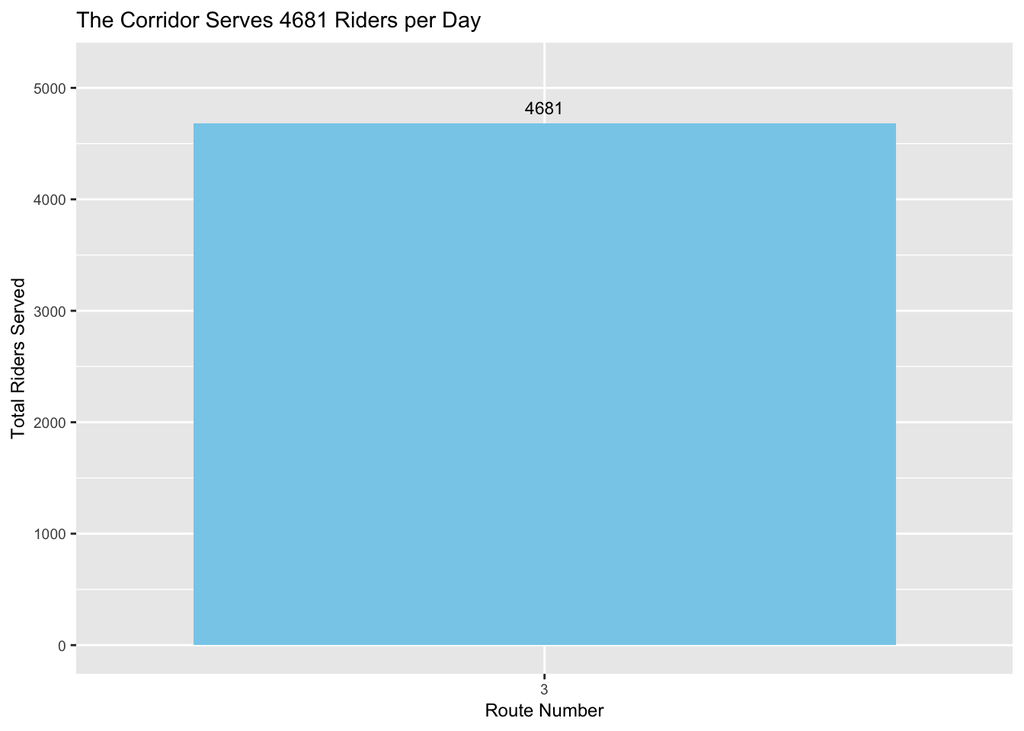

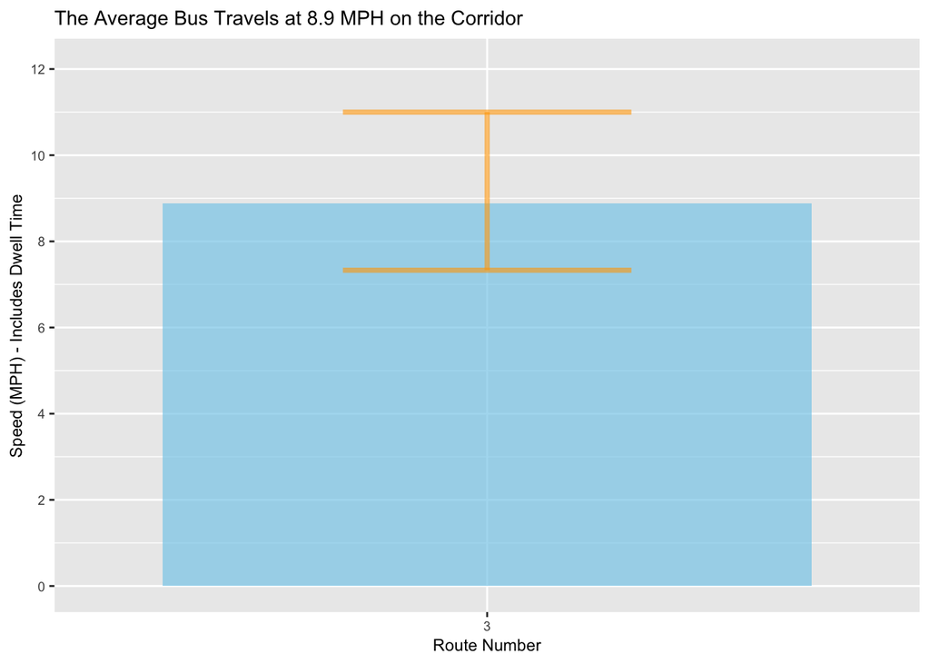

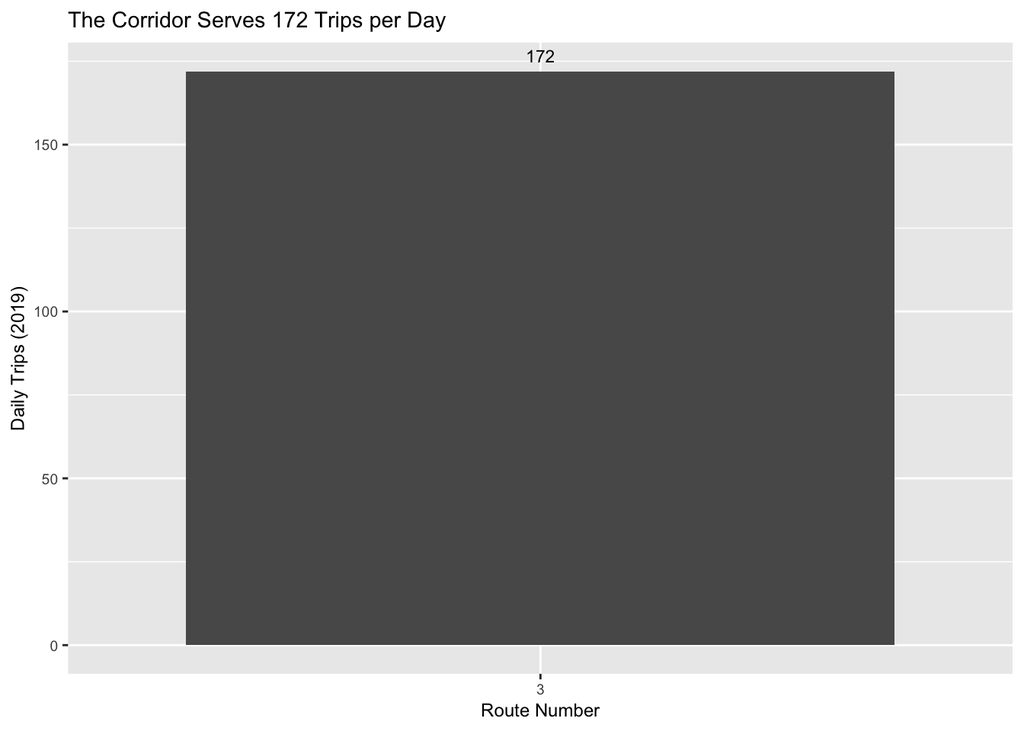

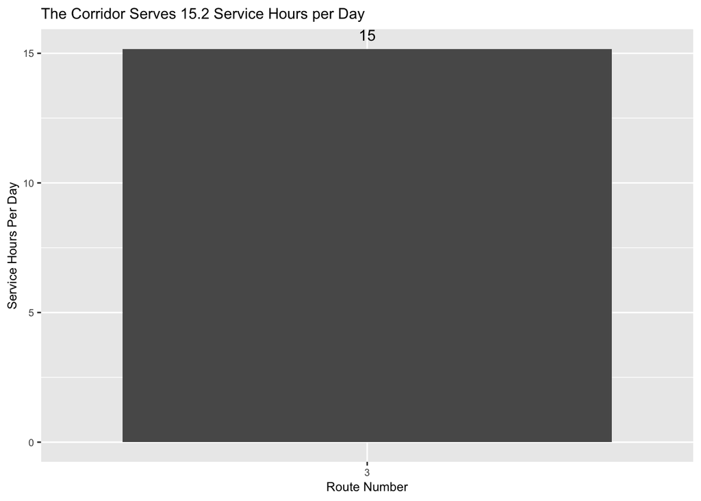

## Period Analytics

| timeframe | daily_ridership | trips | routes_served | service_hours | riders_per_hour | on_off | dwell_observed_mean | dwell_predicted_mean | dwell_hybrid_mean | dwell_per_onoff | onoff_per_trip | onoff_per_tripstop | avg_segment_speed | avg_speed_10_pct | avg_speed_25_pct | avg_speed_75_pct | avg_speed_90_pct |
| --- | --- | --- | --- | --- | --- | --- | --- | --- | --- | --- | --- | --- | --- | --- | --- | --- | --- |
| Early AM | 331 | 25 | 3 | 1.58 | 210.01 | 208 | 41.36 | 29.36 | 41.36 | 0.28 | 8.32 | 1.04 | 11.41 | 9.65 | 10.31 | 11.85 | 13.81 |
| AM Rush | 1287 | 41 | 3 | 3.49 | 368.91 | 957 | 90.59 | 69.34 | 90.59 | 0.34 | 23.34 | 2.92 | 8.64 | 7.48 | 7.97 | 9.23 | 9.86 |
| Afternoon | 1506 | 44 | 3 | 4.44 | 339.44 | 1134 | 115.43 | 86.93 | 115.43 | 0.30 | 25.77 | 3.22 | 7.83 | 6.90 | 7.39 | 8.30 | 8.84 |
| PM Rush | 1194 | 42 | 3 | 4.13 | 288.87 | 865 | 103.43 | 79.18 | 103.43 | 0.26 | 20.60 | 2.57 | 8.32 | 7.03 | 7.58 | 8.82 | 9.28 |
| Evening | 363 | 20 | 3 | 1.54 | 236.14 | 232 | 71.00 | 46.80 | 71.00 | 0.25 | 11.60 | 1.45 | 9.80 | 8.48 | 9.15 | 10.43 | 10.94 |
| Daily | 4681 | 172 | 3 | 15.17 | 308.53 | 3396 | 90.65 | 67.81 | 90.65 | 0.22 | 19.74 | 2.47 | 8.89 | 7.33 | 7.83 | 9.66 | 11.00 |

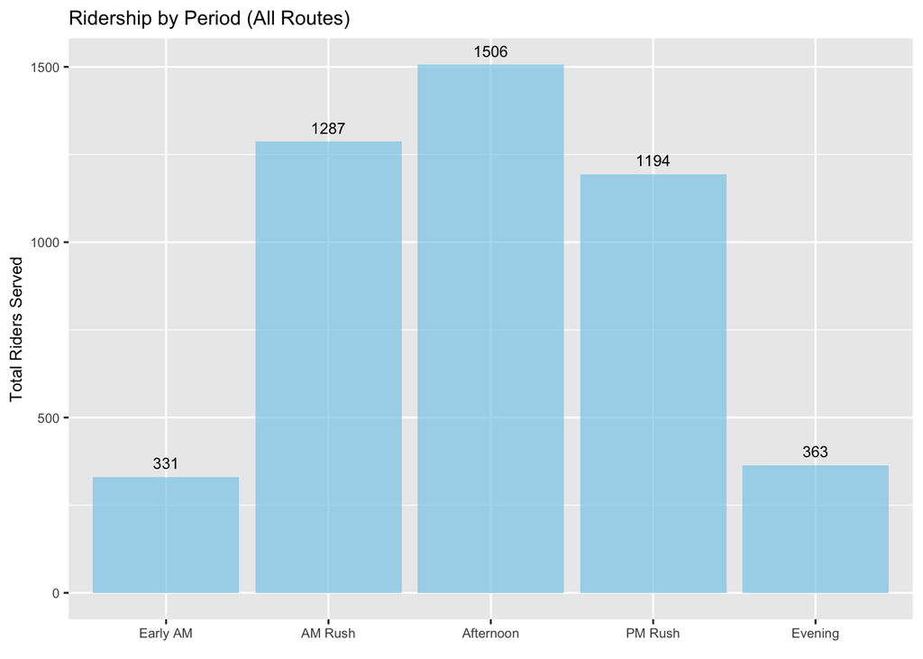

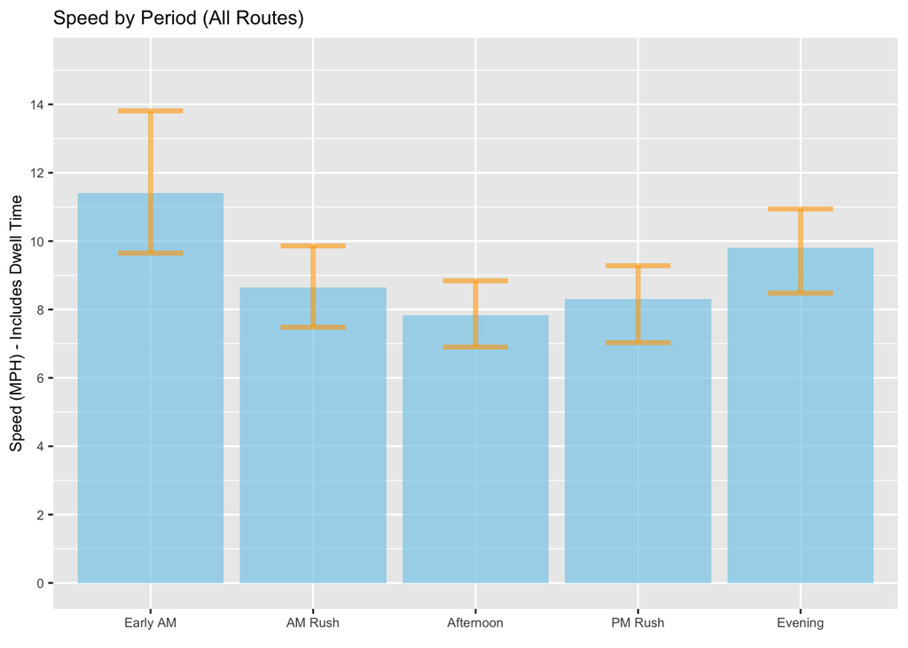

## Hourly Analytics

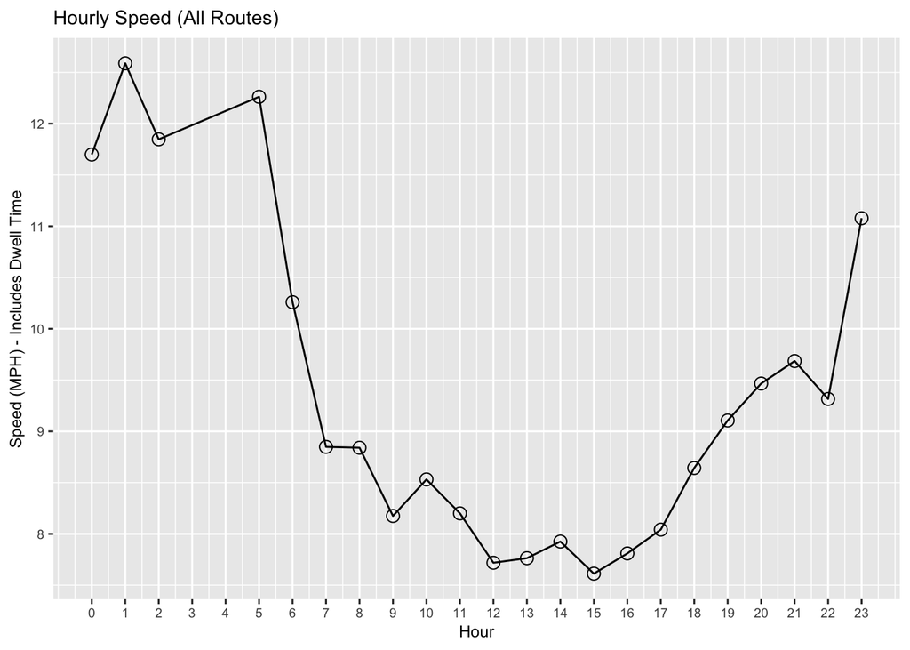

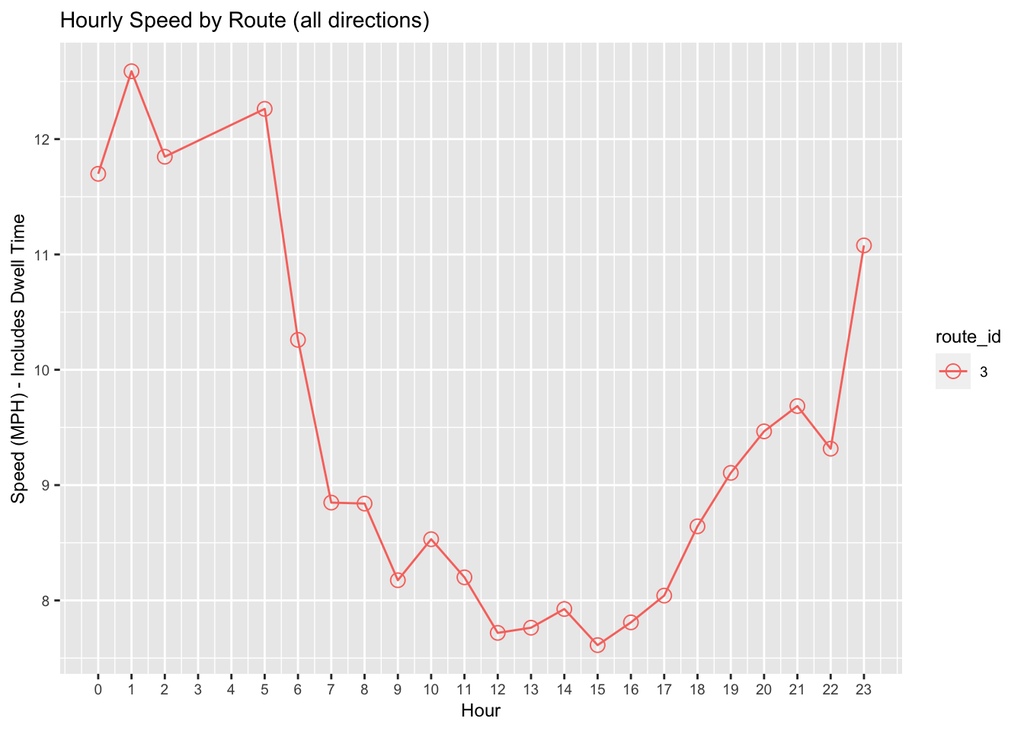

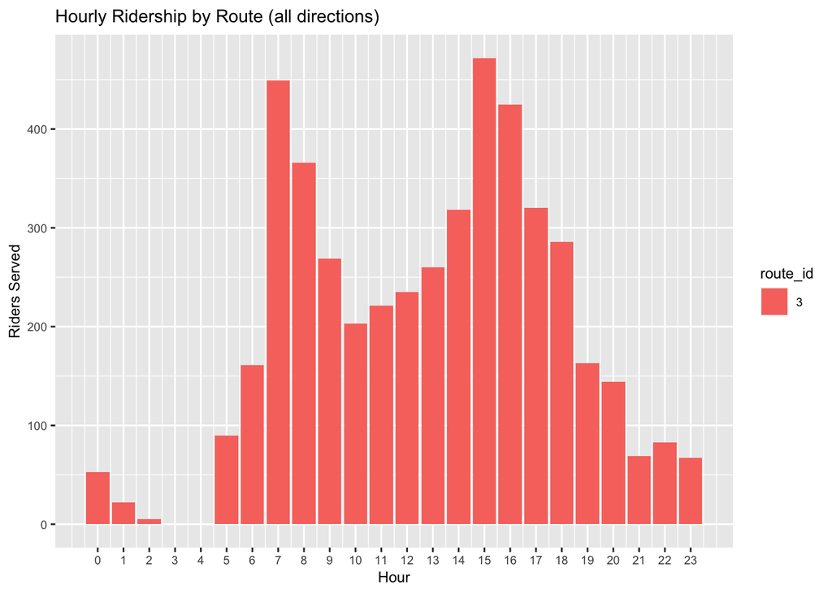

### Hourly Analytics by Direction

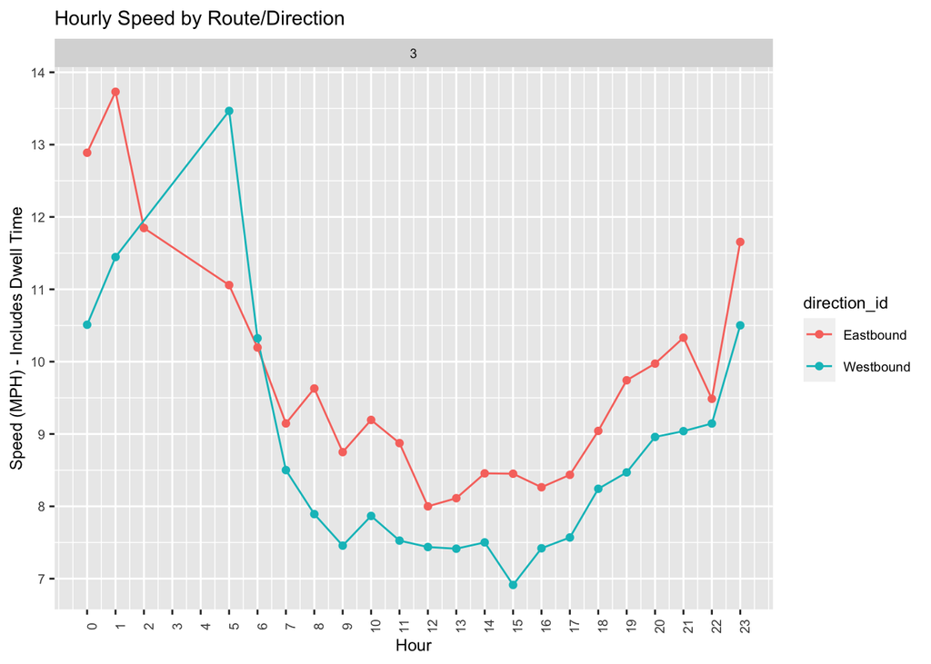

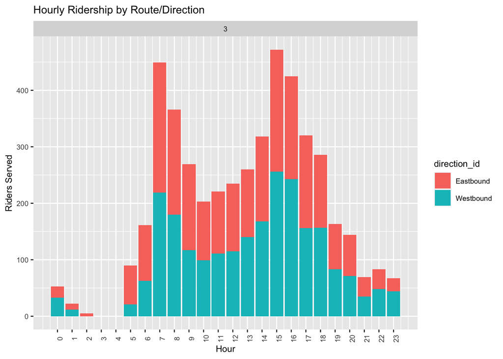

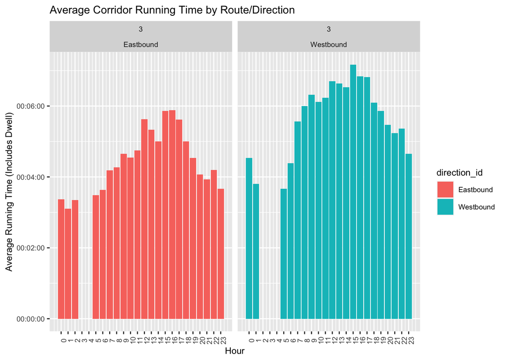

## Value of Potential Improvements

The following represents the value of theoretical improvements to the corridor analyzed above.

### Key Assumptions

This this analysis makes the following assumptions:

1. Reductions will be applied equally across all trips and across the day along the corridor;
2. Running times include dwell times, so savings can be found both through reducing dwell time and improving operating speed; and
3. Any savings in running time can immediately be recouped and/or has inherent monetary value.

### Theoretical Time Savings

The following charts show the potential immprovements that bus lane installation could provide across different levels of time savings, ranging from 5% to 20%. See the Transit Plan’s Toolkit section for a range of potential interventions and guidance on what may succeed on this corridor.

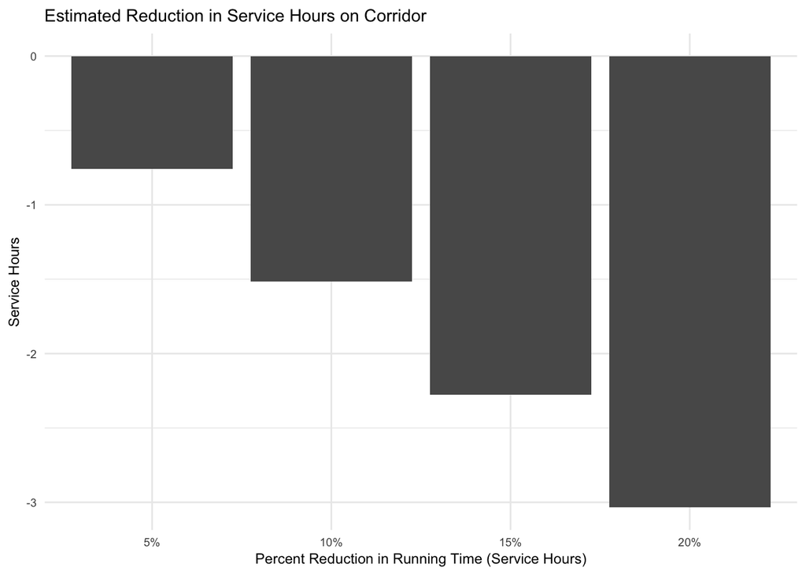

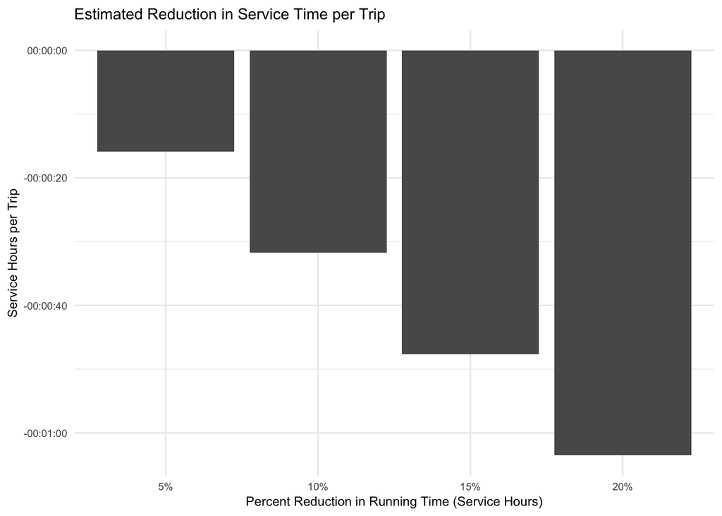

### Value of Time Savings

**Perhaps mostly importantly, however, is the value proposition.** This chart shows the potential cost savings from running time improvements that could be reallocated to additional service.

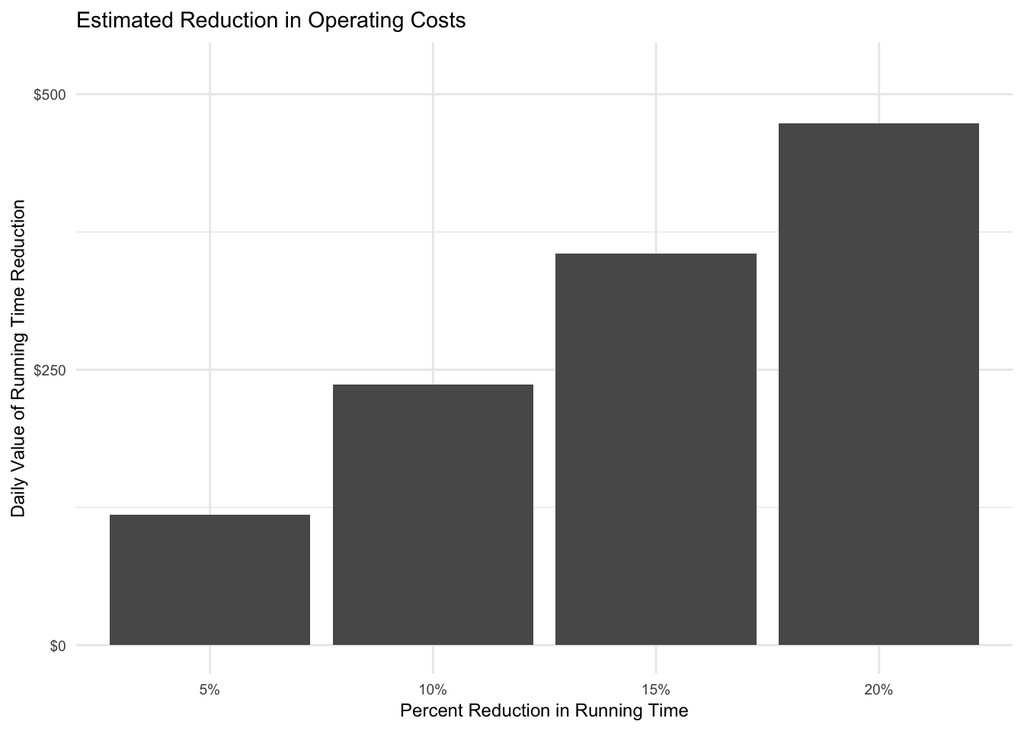

## Results

- A 10% reduction time across a day’s worth of trips could be valued at approximately **$236.76**. Given that there are approximately 250 working weekdays in 2020, this estimate would put value the bus lane at **$59,189.55** per year in terms of operational savings.

These results do not take into account more advanced measures that should be considered when evaluating a Transit First project. Future work should explore:

- Reviewing assumptions about how different improvements generate different time savings;
- Modeling more complexly the disparate impacts of improvements at different times of day;
- More complely modeling the value of time savings at different times of day; and
- Incorporate scheduling information to highlight periods where time savings could “save a bus.”